# Assignment 3

## Variable Comparison Chart

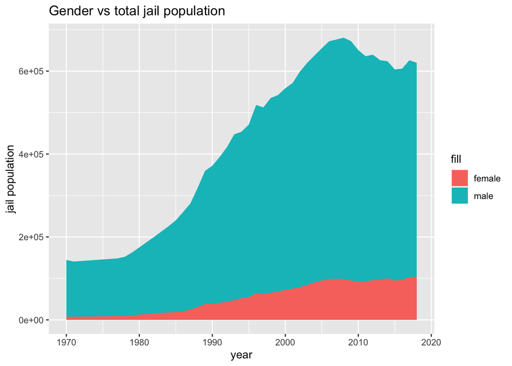

## Map

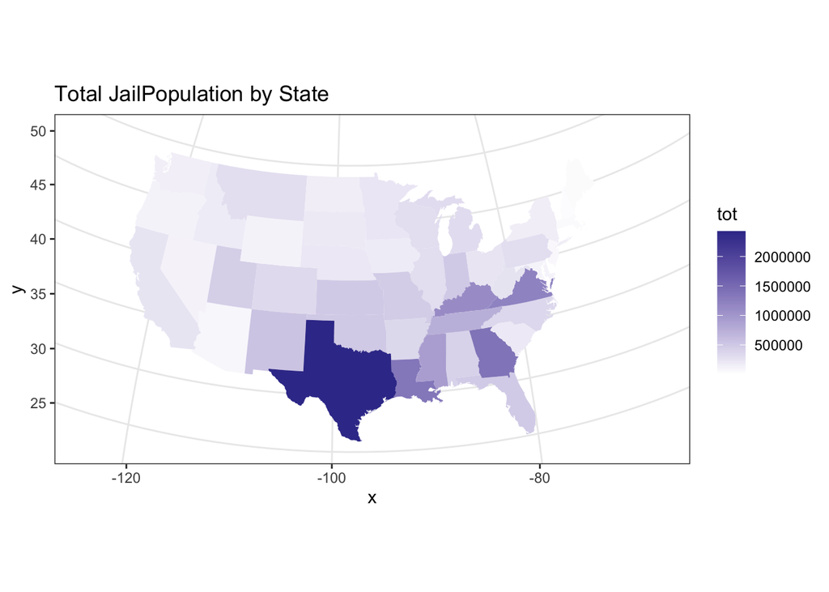

Here, I’m using the state as the unit of analysis to understand the broad contours of incarceration in the US. These shades of purple represent the total jail population rate, and as you can see the darker the color the higher the rate and vice versa. As we can see Texas, Louisiana, Virginia, Kentucky, and Gerogia are the five states that has the highest jail population rate and they are all sorta on the south-east (mainly south) side of the US. It’s be interesting to see the ethnicity of those incarcerated people and see if we can find some pattern there.